# ROCker-Meth

Matteo Benelli, Dario Romagnoli, Alberto Magi

2019-06-06

ROCker-Meth (Receiver Operating Characteristic curve analyzER of DNA Methylation data) tool consists of four main modules:

1. computation of Area Under the Curve (AUC) values from Receiver operating characteristic (ROC) Curve analysis of methylation levels (i.e., beta values) in tumor versus normal samples (**compute_AUC**)
2. segmentation of AUC values by a tailored Hidden Markov Model (HMM) (**find_dmrs**);
3. estimation of the statistical significance of AUC segments by Wilcoxon-Mann-Whitney (WMW) test on beta values of tumor versus normal samples
4. identification of sample specific DMRs by Z-score statistics (**compute_z_scores**).

The package include also a fuction (**write_output**) to easily produce a bed file to visually inspect discovered DMR using a genome browser.

# ROCker-Meth Tutorial

The following tutorial describes the use of Rocker-meth to identify Differentially Methylated Sites (DMSs) with AUC statistics, Differentially Methylated Regions (DMRs) by a tailored Heterogeneous Hidden Markov Model based algorithm and samples supporting DMRs.

First, we need to install the Rocker-meth R package, available at https://github.com/cgplab/ROCkerMeth

```r
# install.packages("devtools")
devtools::install_github("cgplab/ROCkerMeth")
```

Once you have installed the package, you need to load it (with other useful packages)

```r
library(ROCkerMeth)
```

## Prepare the data

You need to properly prepare DNA methylation data. Required data include:

1. Table of beta values (percentage) of tumor samples (samples in columns, CpG sites in rows).
2. Table of beta values (percentage) of normal samples (samples in columns, CpG sites in rows).
3. Data frame reporting chromosomal and genomic position of each CpG site.

As an example, we will use a subset of the Prostate Adenocarcinoma dataset from TCGA (PRAD). To to the fact that we will use only 20 TP and 10 NT samples, results are markedly different with respect to the original dataset. Subset data have been already prepared and available from the ROCkerMeth package.

```r
head(PRAD_TP_subset[, 1:5])
```

```
##            TCGA-2A-A8VV-01A-11D-A378-05 TCGA-2A-A8W1-01A-11D-A378-05
## cg00000029                            8                            6
## cg00000108                           NA                           NA
## cg00000109                           NA                           NA
## cg00000165                           80                            6
## cg00000236                           90                           90
## cg00000289                           69                           63
##            TCGA-CH-5737-01A-11D-1578-05 TCGA-CH-5741-01A-11D-1578-05
## cg00000029                           13                            5
## cg00000108                           NA                           NA
## cg00000109                           NA                           NA
## cg00000165                            7                           21
## cg00000236                           84                           92
## cg00000289                           74                           75
##            TCGA-CH-5748-01A-11D-1578-05
## cg00000029                            8
## cg00000108                           NA
## cg00000109                           NA
## cg00000165                           22
## cg00000236                           89
## cg00000289                           67
```

```r
head(PRAD_NT_subset[, 1:5])
```

```
##            TCGA-CH-5761-11A-01D-1578-05 TCGA-CH-5762-11A-01D-1578-05
## cg00000029                            9                           10
## cg00000108                           NA                           NA
## cg00000109                           NA                           NA
## cg00000165                           10                           11
## cg00000236                           91                           90
## cg00000289                           67                           68
##            TCGA-CH-5763-11A-01D-1578-05 TCGA-CH-5764-11A-01D-1578-05
## cg00000029                            9                           12
## cg00000108                           NA                           NA
## cg00000109                           NA                           NA
## cg00000165                           35                           13
## cg00000236                           74                           88
## cg00000289                           77                           78
##            TCGA-CH-5765-11A-01D-1578-05
## cg00000029                            6
## cg00000108                           NA
## cg00000109                           NA
## cg00000165                           15
## cg00000236                           91
## cg00000289                           77
```

```r
head(illumina450k_hg19)
```

```
## # A tibble: 6 x 4
##   `Composite Element REF` Gene_Symbol Chromosome Genomic_Coordinate
##   <chr>                   <chr>       <chr>                   <int>
## 1 cg00000029              RBL2        16                   53468112
## 2 cg00000108              C3orf35     3                    37459206
## 3 cg00000109              FNDC3B      3                   171916037
## 4 cg00000165              <NA>        1                    91194674
## 5 cg00000236              VDAC3       8                    42263294
## 6 cg00000289              ACTN1       14                   69341139
```

## Identification of Differentially Methylated Sites (DMSs) by AUC

Rocker-meth uses AUC statistics to identify DMSs. It implements a function (**compute_AUC**) able to perform parallel computing of the AUC for each site. This step takes a while. In case, you can increase *ncores* parameter to calculate AUCs faster).

```r
PRAD_auc <- compute_AUC(tumor_table = PRAD_TP_subset, control_table = PRAD_NT_subset,
                        ncores = 2, na_threshold = 0)
```

```r
head(PRAD_auc)
```

```
## [1] 0.5075     NA     NA 0.7100 0.6500 0.3475
```

`na_threshold` refers to the fraction of samples permitted to be NA at a give site (no beta value available). By setting it to 0, we will calculate AUC only for those sites having complete data (i.e. available beta value for all tumor and normal samples). Now, you can look at the distribution of AUCs and visually estimate the fraction of hypo (AUC < 0.2) and hyper (AUC > 0.8) DMSs.

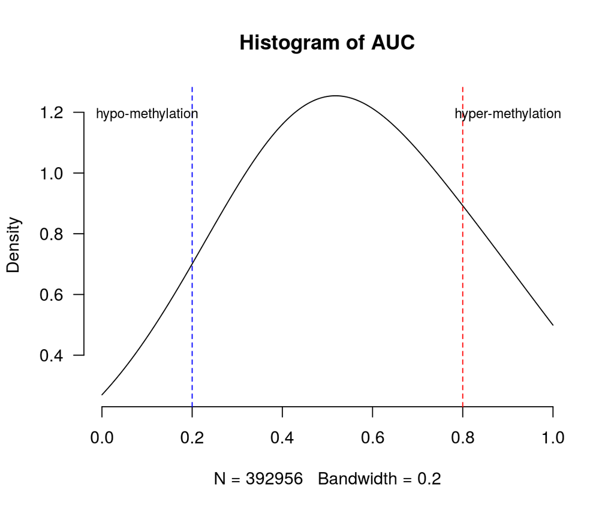

```r
auc_density <- density(PRAD_auc, bw = 0.2, from = 0, to = 1, na.rm = TRUE)
{plot(auc_density, main="Histogram of AUC", frame.plot = FALSE, col = "black", las = 1)
abline (v = c(0.2, 0.8), col = c("blue", "red"), lty = 2)
text(.1, max(auc_density$y*0.95), "hypo-methylation", cex = .8)
text(.9, max(auc_density$y*0.95), "hyper-methylation", cex = .8)}
```

You can print and write a table reporting DMS analysis and related annotation:

```r
## calculate average beta value per site in both tumor (TP) and normal (NT) samples
avg_beta_tp <- apply(PRAD_TP_subset, 1, mean, na.rm = TRUE)
avg_beta_nt <- apply(PRAD_NT_subset, 1, mean, na.rm = TRUE)
## create a flag for differential methylation analysis
dms_flag <- rep(NA, length(PRAD_auc))
dms_flag[which(PRAD_auc > 0.8)] <- "hyper"
dms_flag[which(PRAD_auc < 0.2)] <- "hypo"
## create the table
dms_table <- cbind(illumina450k_hg19, avg_beta_nt, avg_beta_tp, PRAD_auc, dms_flag)
head(dms_table)
```

```
##            Composite Element REF Gene_Symbol Chromosome Genomic_Coordinate
## cg00000029            cg00000029        RBL2         16           53468112
## cg00000108            cg00000108     C3orf35          3           37459206
## cg00000109            cg00000109      FNDC3B          3          171916037
## cg00000165            cg00000165        <NA>          1           91194674
## cg00000236            cg00000236       VDAC3          8           42263294
## cg00000289            cg00000289       ACTN1         14           69341139
##            avg_beta_nt avg_beta_tp PRAD_auc dms_flag
## cg00000029         9.3        9.45   0.5075     <NA>
## cg00000108         NaN         NaN       NA     <NA>
## cg00000109         NaN         NaN       NA     <NA>
## cg00000165        21.3       48.65   0.7100     <NA>
## cg00000236        86.3       89.20   0.6500     <NA>
## cg00000289        73.5       71.35   0.3475     <NA>
```

```r
#write.table(dms_table, file = "Table_DMS.txt", sep = "\t", row.names = FALSE, quote = FALSE)
```

draw a plot like the following

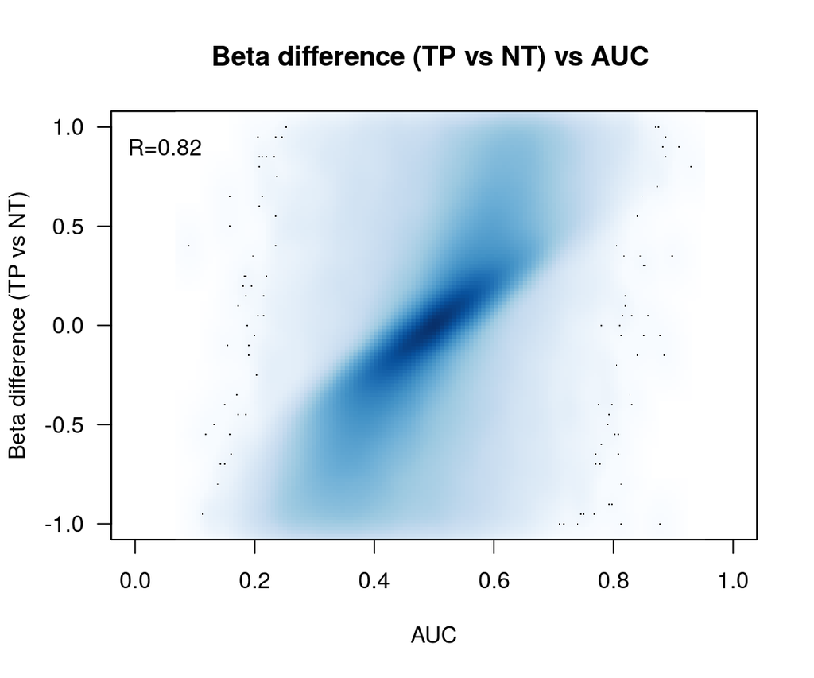

```r
cor_auc_betadiff <- cor(dms_table$PRAD_auc, (dms_table$avg_beta_tp-dms_table$avg_beta_nt), use = "na")
{smoothScatter(dms_table$PRAD_auc, (dms_table$avg_beta_tp-dms_table$avg_beta_nt), main="Beta difference (TP vs NT) vs AUC ",
              xlab = "AUC", ylab = "Beta difference (TP vs NT)", las = 1, xlim = c(0, 1),
              ylim = c(-1, 1))
text(0.05, .9, paste0("R=", format(cor_auc_betadiff, digits = 2) ))}
```

and order data by most significant differentially methylated sites

```r
dms_table.srt <- dms_table[order(abs(dms_table$PRAD_auc-0.5), decreasing = TRUE), ]
head(dms_table.srt)
```

```
##            Composite Element REF Gene_Symbol Chromosome Genomic_Coordinate
## cg00002033            cg00002033       LRFN1         19           39798481
## cg00003578            cg00003578        <NA>          1           12600529
## cg00007076            cg00007076        RRS1          8           67342600
## cg00009196            cg00009196        RIN2         20           19954588
## cg00017062            cg00017062        <NA>         15           70669548
## cg00017826            cg00017826        <NA>          2           30644955
##            avg_beta_nt avg_beta_tp PRAD_auc dms_flag
## cg00002033        35.9       74.30        1    hyper
## cg00003578        50.9       73.10        1    hyper
## cg00007076        31.4       10.25        0     hypo
## cg00009196        46.1       77.25        1    hyper
## cg00017062        33.7       77.75        1    hyper
## cg00017826        68.7       94.50        1    hyper
```

## Identification of Differentially Methylated Regions (DMRs) by HMM

```r
head(dmr_table)
```

```
## # A tibble: 6 x 8
##   chr    start    end nsites state avg_beta_diff   p_value  q_value
##   <chr>  <int>  <int>  <dbl> <int>         <dbl>     <dbl>    <dbl>
## 1 1      15865 844499     75     2          NA   NA        NA
## 2 1     845311 849540     13     3          16.9  0.0128    0.0347
## 3 1     853876 916058    125     2          NA   NA        NA
## 4 1     916346 919916     14     1         -12.2  0.0771    0.108
## 5 1     931327 941382     25     2          NA   NA        NA
## 6 1     942161 943064     11     3          24.4  0.000930  0.00570
```

You can draw a vulcano plot to identify significant DMRs (GSTP1 is highlighted)

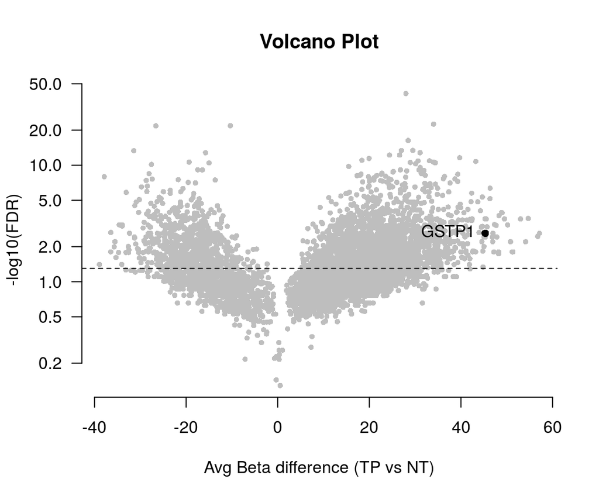

```r
{plot(dmr_table$avg_beta_diff, -log10(dmr_table$q_value), main= "Volcano Plot", log = "y", las = 1,
     frame.plot = FALSE, pch = 16, col = "grey",
     ylab = "-log10(FDR)", xlab = "Avg Beta difference (TP vs NT)", cex = .7)
gstp1 <- which(dmr_table$chr == "11" & dmr_table$start < 67351000 & dmr_table$end > 67351000)
points(dmr_table$avg_beta_diff[gstp1], -log10(dmr_table$q_value)[gstp1], pch = 16, cex = 1, col = "black")
text(dmr_table$avg_beta_diff[gstp1], -log10(dmr_table$q_value)[gstp1], "GSTP1", pos = 2)
abline(h = -log10(0.05), lty = 2)}
```

Now you can perform single sample analysis by Z-score statistics (it takes a while)

```r
PRAD_sample_score <- compute_z_scores(tumor_table = PRAD_TP_subset, control_table = PRAD_NT_subset,
                                dmr_table = dmr_table, reference_table = illumina450k_hg19[3:4],
                                min_size = 6)
```

```r
head(PRAD_sample_score$z_scores[, 1:5])
```

```
##                    TCGA-2A-A8VV-01A-11D-A378-05
## chr1:15865-844499                     0.3854233
## chr1:845311-849540                    1.6602849
## chr1:853876-916058                    1.7986420
## chr1:916346-919916                   -2.3607177
## chr1:931327-941382                   -0.6744908
## chr1:942161-943064                    1.1650295
##                    TCGA-2A-A8W1-01A-11D-A378-05
## chr1:15865-844499                    -0.8672024
## chr1:845311-849540                    2.5941952
## chr1:853876-916058                    2.5855479
## chr1:916346-919916                   -6.1378659
## chr1:931327-941382                    0.0000000
## chr1:942161-943064                    2.2687416
##                    TCGA-CH-5737-01A-11D-1578-05
## chr1:15865-844499                    -1.2526257
## chr1:845311-849540                    1.9715884
## chr1:853876-916058                    0.5620756
## chr1:916346-919916                   -6.4076622
## chr1:931327-941382                   -0.6744908
## chr1:942161-943064                    4.9667047
##                    TCGA-CH-5741-01A-11D-1578-05
## chr1:15865-844499                     -1.059914
## chr1:845311-849540                     0.518839
## chr1:853876-916058                     3.147624
## chr1:916346-919916                    -6.947255
## chr1:931327-941382                    -1.348982
## chr1:942161-943064                     3.372454
##                    TCGA-CH-5748-01A-11D-1578-05
## chr1:15865-844499                    -0.5781349
## chr1:845311-849540                    2.0753562
## chr1:853876-916058                    2.6979630
## chr1:916346-919916                   -2.0909214
## chr1:931327-941382                   -0.6744908
## chr1:942161-943064                    2.7592804
```

Finally, the table of DMRs and sample scores can be written in a bed or a seg file to be viewed with genomic browser, such as IGV.

```r
write_output(path = "~/PRAD.subset", dmr_table = dmr_table, sample_score = PRAD_sample_score)
```

## Rocker-meth with different parameter settings

In our parameter study, we observed that our method is very sensible to changes in F. F is the parameter used to split the total AUC signal variance in two parts: the variance of not differentially methylated state and the variance of differentially methylated states. Here we will see how Rocker-meth results are affected by the parameter F from its standard value (0.4) to different values. Based on our study, we expect that lowering F will increase specificity at the cost of sensitivity. The opposite situation occurs for larger values of F.

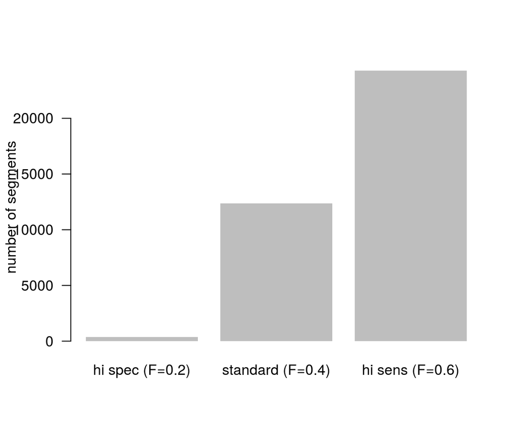

```r
barplot(dat_n_seg, border = NA, las = 1, ylab = "number of segments", beside = TRUE)
```

We can nicely demostrate that modulating F affects sensibility/sensitivity trade-off by looking at the distribution of p-values of DMRs in the three settings.

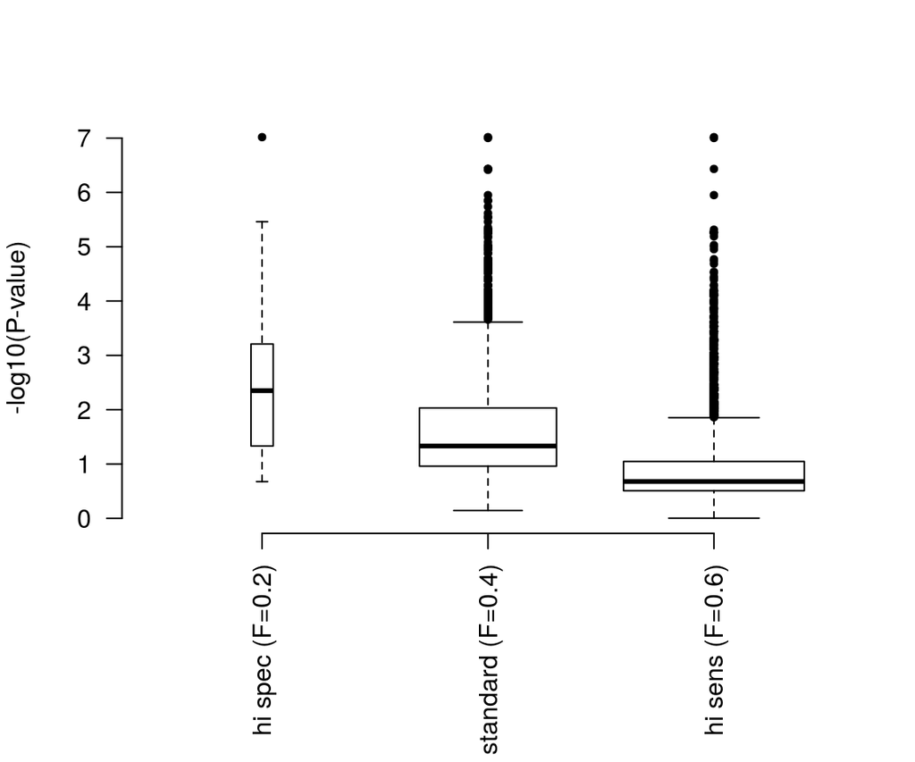

```r
## to make p-values comparable, we will focus on DMRs of <15 CpG sites in length

nsites <- 15
mybox <- list(-log10(dmr_table_hi_specificity$p_value[which(dmr_table_hi_specificity$nsites<nsites & dmr_table_hi_specificity$state != 2)]),
              -log10(dmr_table$p_value[which(dmr_table$nsites<nsites & dmr_table$state != 2)]),
              -log10(dmr_table_hi_sensitivity$p_value[which(dmr_table_hi_sensitivity$nsites<nsites & dmr_table_hi_sensitivity$state != 2)]))
names(mybox) <- names(dat_n_seg)
{
  par (mar = c(7.5, 4, 4, 2))
  boxplot(mybox, varwidth = TRUE, las = 2, ylab = "-log10(P-value)", frame.plot = FALSE, pch = 19, cex = .6)
}
```

## Identify candidate subtype specific DMRs

Here we will see a strategy that can be used to identify DMRs specific to molecular subtypes. Also in this case we will consider the PRAD dataset. characterized by 8 molecular subytpes (TCGA-PRAD Consortium, Cell 2015).

```r
head (PRAD_molecular_subtypes)
```

```
##     PATIENT_ID Subtype
## 1 TCGA-HC-7818   1-ERG
## 2 TCGA-HC-7077   1-ERG
## 3 TCGA-G9-6356   1-ERG
## 4 TCGA-HC-7213   1-ERG
## 5 TCGA-KK-A6E1   1-ERG
## 6 TCGA-VP-A872   1-ERG
```

```r
table(PRAD_molecular_subtypes$Subtype)
```

```
##
##   1-ERG  2-ETV1  3-ETV4  4-FLI1  5-SPOP 6-FOXA1  7-IDH1 8-other
##     152      28      14       4      37       9       3      86
```

Subtype specific DMRs can be identified as those showing different Z-score statistics across the different subtypes. First, we match methylation sample IDs with patient ID.

```r
subtypes <- names(table(PRAD_molecular_subtypes$Subtype))
subtype_data <- rep(NA, ncol(PRAD_TP_subset))
for (subtype in subtypes) {
  ix <- which(substr(colnames(PRAD_TP_subset), 1, 12) %in% PRAD_molecular_subtypes$PATIENT_ID[which(PRAD_molecular_subtypes$Subtype == subtype)])
  subtype_data[ix] <- subtype
}
## subtypes in PRAD subset
table(subtype_data)
```

```
## subtype_data
##   1-ERG  2-ETV1  5-SPOP 6-FOXA1
##      10       3       5       2
```

A reasonable strategy to identify candidates subtype specific DMRs is by using one-way ANOVA test.

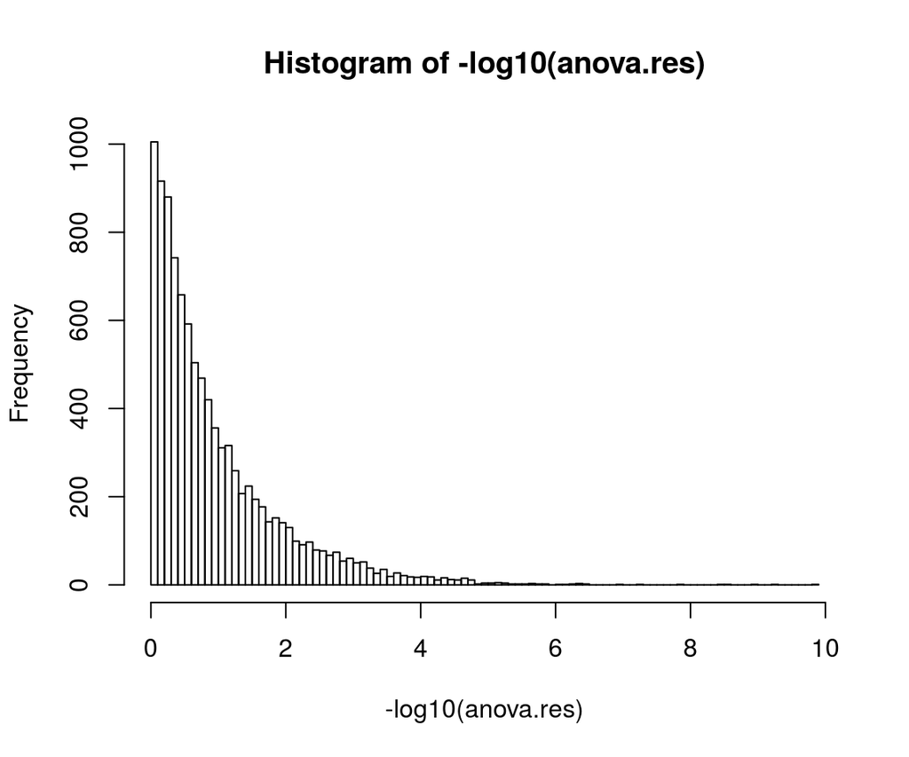

```r
## exclude DMRs with not estimated Z-score in all sample
## Attention: it can take a while
anova.res <- rep(NA, nrow(PRAD_sample_score$z_scores))
for (i in 1: length(anova.res)) {
  if (all(is.finite(PRAD_sample_score$z_scores[i, ]))) {
  anova.res[i] <- summary(aov(PRAD_sample_score$z_scores[i, ] ~ subtype_data))[[1]][1,5]
  }
}
## create histogram of ANOVA p-values
hist(-log10(anova.res), 100)
```

Finally, we can check if candidate subtype specific DMRs are actually specific of one (or more) subtype.

```r
## how many DMRs with p < 1e-5
j <- which(anova.res < 1e-5)
anova.res[j]
```

```
##  [1] 0.0000061860904831 0.0000000001470885 0.0000000005181367
##  [4] 0.0000017325665984 0.0000042785074183 0.0000015437264474
##  [7] 0.0000020745370191 0.0000081527920983 0.0000000550368400
## [10] 0.0000059337324655 0.0000026984945749 0.0000004435153332
## [13] 0.0000013612401676 0.0000015857033865 0.0000066952922019
## [16] 0.0000003563478959 0.0000073035450196 0.0000074053830573
## [19] 0.0000086023961824 0.0000080763801309 0.0000000027056361
## [22] 0.0000095875027397 0.0000004961835016 0.0000049499606138
## [25] 0.0000005147479159 0.0000037150625771 0.0000005244969898
## [28] 0.0000019982467380 0.0000004755478285 0.0000060806996346
## [31] 0.0000068556269137 0.0000006507803077 0.0000000036094400
## [34] 0.0000008290659469 0.0000053820151346 0.0000068740420437
## [37] 0.0000034104080115 0.0000000011065226 0.0000027440427171
## [40] 0.0000000129209609 0.0000001165857332 0.0000003215584205
## [43] 0.0000023980576097
```

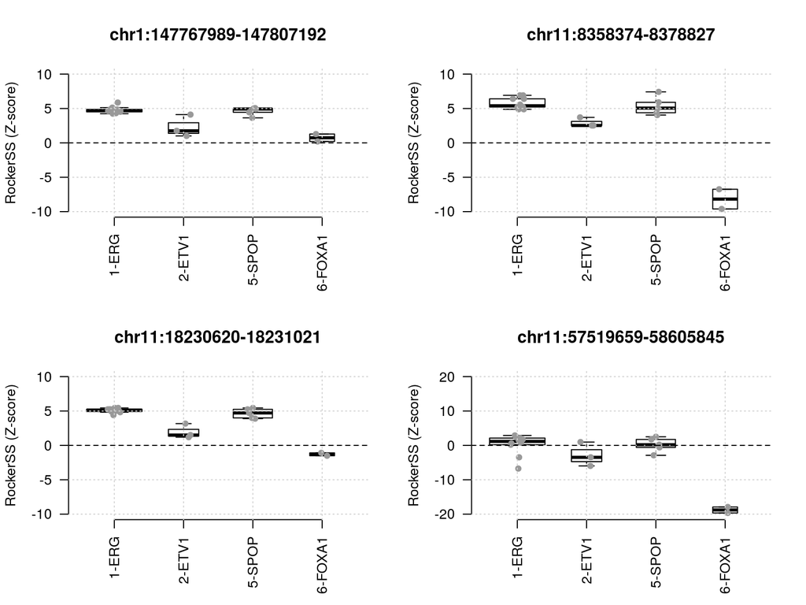

```r
## As an exmaple, plot the firsts
{
  par (mfrow = c(2, 2))
  for (i in 1: 4) {
    mymax <- round(max(abs(PRAD_sample_score$z_scores[j[i], ]))/10)*10
      boxplot(PRAD_sample_score$z_scores[j[i], ] ~ subtype_data, varwidth = TRUE, outline = FALSE, ylim = c(-mymax, mymax),
        frame.plot = FALSE, las = 2, ylab = "RockerSS (Z-score)",
        main = rownames(PRAD_sample_score$z_scores[j, ])[i])
    stripchart(PRAD_sample_score$z_scores[j[i], ] ~ subtype_data, pch = 19, col = "grey60",
           vertical = TRUE, method = "jitter", add = TRUE)
    grid()
    abline (h = 0, lty = 2)

  }
}
```

In these boxplots, we see that the first case and third case (left) show DMRs with pronounced hyper-methylation in ERG and SPOP subtypes, second and fourth cases (right) show DMRs that are clearly hypo-methylated in FOXA1 subtype and not in the other subtypes.

## Additonal info, code and data

https://github.com/cgplab/ROCkerMeth

## Citation

#### Pan-cancer characterization of differentially DNA methylated regions enabled by Rocker-meth. Benelli et al., submitted.